# project

# A. discussion of data quality

```r
library(tidyverse)
library(skimr)
library(readxl) # to read in the xlsx file
library(naniar) #for replacing 6 with NA
# install packages needed for ANCOVA analysis as per the "Discovering Statistics Using R" book by Field, Miles and Field
#install.packages("car"); install.packages("akima"); install.packages("compute.es"); install.packages ("effects");install.packages("ggplot2");install.packages("multcomp");install.packages("pastecs"); install.packages("WRS", repos="http://R-Forge.R-project.org")
# load ANCOVA relate libraries after installing them
library(car); # for Levene’s test, Type III sums of squares
library(compute.es); # for effect sizes
library(effects); # for adjusted means
library(ggplot2); # for graphs
library(multcomp); # for post hoc tests
library(pastecs); # for descriptive statistics
library(WRS) # for robust tests

project_data <- read_excel("raw_data.xlsx", sheet = 1)
glimpse(project_data)
```

```
## Observations: 1,377
## Variables: 46
## $ subid      <dbl> 1, 2, 3, 4, 5, 6, 7, 8, 9, 10, 11, 12, 13, 14, 15, ...
## $ study      <dbl> 1, 1, 1, 1, 1, 1, 1, 1, 1, 1, 1, 1, 1, 1, 1, 1, 1, ...
## $ condcoat   <dbl> 1, 1, 1, 1, 1, 1, 1, 1, 1, 1, 1, 1, 1, 1, 1, 1, 1, ...
## $ condemp    <dbl> 0, 1, 1, 0, 0, 1, 0, 1, 0, 1, 1, 0, 0, 0, 0, 0, 1, ...
## $ COMP1      <dbl> 1, 4, 4, 3, 3, 3, 5, 5, 5, 5, 3, 4, 5, 3, 3, 5, 5, ...
## $ COMP2      <dbl> 1, 4, 3, 3, 4, 4, 5, 5, 4, 5, 4, 5, 5, 3, 3, 5, 5, ...
## $ COMP3      <dbl> 1, 4, 2, 3, 3, 3, 4, 4, 4, 3, 3, 4, 3, 4, 3, 3, 3, ...
## $ COMP4      <dbl> 4, 4, 2, 3, 3, 2, 1, 2, 2, 2, 3, NA, 5, 2, 1, 2, 1,...
## $ COMP5      <dbl> 1, 5, 4, 3, 4, 3, 5, 4, 5, 5, 3, 4, 5, 3, 2, 3, 5, ...
## $ WARM1      <dbl> 1, 4, 4, 3, 3, 3, 3, 3, 4, 4, 2, 1, 5, 3, 2, 4, 4, ...
## $ WARM2      <dbl> 1, 4, 3, 2, 2, 4, 2, 5, 3, 3, 2, 1, 5, 1, 1, 2, 5, ...
## $ WARM4      <dbl> 1, 4, 3, 2, 3, 2, 3, 4, 4, 4, 3, 1, 5, 1, 1, 2, 5, ...
## $ WARM3      <dbl> 1, 4, 4, 2, 2, 3, 4, 4, 4, 4, 3, 1, 5, 1, 2, 2, 5, ...
```

[output cut: 33 more lines]

```r
skim(project_data)
```

```
## Skim summary statistics
##  n obs: 1377
##  n variables: 46
##
## ── Variable type:numeric ────────────────────────────────────────────────────────────────────────────────────────────
##    variable missing complete    n   mean     sd p0 p25 p50  p75 p100
##       CARE1       5     1372 1377   2.72   1.46  1   1   3    4    6
##      CARE10       5     1372 1377   2.56   1.47  1   1   2    4    6
##       CARE2       5     1372 1377   2.57   1.57  1   1   2    4    6
##       CARE3       5     1372 1377   2.59   1.52  1   1   2    4    6
##       CARE4       5     1372 1377   2.39   1.51  1   1   2    4    6
##       CARE5       5     1372 1377   2.68   1.49  1   1   2    4    6
##       CARE6       5     1372 1377   2.58   1.49  1   1   2    4    6
##       CARE7       5     1372 1377   3.26   1.37  1   2   3    4    6
##       CARE8       5     1372 1377   2.48   1.39  1   1   2    4    6
##       CARE9       5     1372 1377   2.43   1.53  1   1   2    3    6
##       COMP1      30     1347 1377   3.63   1.09  1   3   4    4    5
##       COMP2      19     1358 1377   3.9    1.05  1   3   4    5    5
##       COMP3     173     1204 1377   3.37   1.09  1   3   3    4    5
##       COMP4     269     1108 1377   2.25   1.2   1   1   2    3    5
##       COMP5      37     1340 1377   3.71   1.02  1   3   4    4    5
##    condcoat       0     1377 1377   0.57   0.5   0   0   1    1    1
##     condemp       0     1377 1377   0.5    0.5   0   0   1    1    1
##   PANASNEG1       6     1371 1377   1.87   1.18  1   1   1    2    5
##  PANASNEG10       6     1371 1377   1.75   1.18  1   1   1    2    5
##   PANASNEG2       6     1371 1377   1.8    1.17  1   1   1    2    5
##   PANASNEG3       6     1371 1377   1.24   0.64  1   1   1    1    5
##   PANASNEG4       6     1371 1377   1.76   1.21  1   1   1    2    5
##   PANASNEG5       6     1371 1377   1.4    0.82  1   1   1    1    5
##   PANASNEG6       6     1371 1377   1.73   1.03  1   1   1    2    5
##   PANASNEG7       6     1371 1377   1.26   0.7   1   1   1    1    5
##   PANASNEG8       6     1371 1377   1.97   1.31  1   1   1    3    5
##   PANASNEG9       6     1371 1377   1.75   1.12  1   1   1    2    5
##   PANASPOS1       6     1371 1377   3.19   1.13  1   2   3    4    5
##  PANASPOS10       6     1371 1377   2.47   1.18  1   1   2    3    5
##   PANASPOS2       6     1371 1377   1.88   1.08  1   1   1    3    5
##   PANASPOS3       6     1371 1377   2.49   1.21  1   1   2    3    5
##   PANASPOS4       6     1371 1377   2.19   1.15  1   1   2    3    5
##   PANASPOS5       6     1371 1377   1.99   1.19  1   1   1    3    5
##   PANASPOS6       6     1371 1377   3.44   1.11  1   3   4    4    5
```

[output cut: 44 more lines]

```
##  ▇▅▁▅▁▂▁▁
##  ▇▃▁▃▁▂▁▁
##  ▂▂▁▆▁▇▁▃
##  ▇▃▁▃▁▂▁▁
##  ▆▆▁▇▁▇▁▃
##  ▁▂▁▅▁▇▁▅
##  ▅▁▁▁▁▁▁▇
##  ▃▁▇▁▁▇▁▇
##  ▇▇▇▇▇▇▇▇
##  ▃▆▁▇▁▇▁▃
##  ▇▇▁▆▁▆▁▅
##  ▅▇▁▇▁▇▁▆
##  ▅▆▁▇▁▇▁▆
##  ▇▁▁▁▁▁▁▇
##  ▇▁▁▁▁▁▁▅
```

## Tidied Data

```r
project_data_tidied <- project_data %>%
  dplyr::select(-X__1, -X__2) %>%
  replace_with_na_at(.vars = c("CARE1", "CARE2", "CARE3", "CARE4", "CARE5", "CARE6", "CARE7", "CARE8", "CARE9", "CARE10"),
                     condition = ~.x == 6)
project_data_tidied
```

```
## # A tibble: 1,377 x 44
##    subid study condcoat condemp COMP1 COMP2 COMP3 COMP4 COMP5 WARM1 WARM2
##    <dbl> <dbl>    <dbl>   <dbl> <dbl> <dbl> <dbl> <dbl> <dbl> <dbl> <dbl>
##  1     1     1        1       0     1     1     1     4     1     1     1
##  2     2     1        1       1     4     4     4     4     5     4     4
##  3     3     1        1       1     4     3     2     2     4     4     3
##  4     4     1        1       0     3     3     3     3     3     3     2
##  5     5     1        1       0     3     4     3     3     4     3     2
##  6     6     1        1       1     3     4     3     2     3     3     4
##  7     7     1        1       0     5     5     4     1     5     3     2
##  8     8     1        1       1     5     5     4     2     4     3     5
##  9     9     1        1       0     5     4     4     2     5     4     3
## 10    10     1        1       1     5     5     3     2     5     4     3
## # ... with 1,367 more rows, and 33 more variables: WARM4 <dbl>,
## #   WARM3 <dbl>, CARE1 <dbl>, CARE2 <dbl>, CARE3 <dbl>, CARE4 <dbl>,
## #   CARE5 <dbl>, CARE6 <dbl>, CARE7 <dbl>, CARE8 <dbl>, CARE9 <dbl>,
## #   CARE10 <dbl>, PANASPOS1 <dbl>, PANASNEG1 <dbl>, PANASPOS2 <dbl>,
## #   PANASNEG2 <dbl>, PANASPOS3 <dbl>, PANASNEG3 <dbl>, PANASNEG4 <dbl>,
## #   PANASNEG5 <dbl>, PANASPOS4 <dbl>, PANASPOS5 <dbl>, PANASNEG6 <dbl>,
## #   PANASPOS6 <dbl>, PANASNEG7 <dbl>, PANASPOS7 <dbl>, PANASNEG8 <dbl>,
## #   PANASPOS8 <dbl>, PANASPOS9 <dbl>, PANASNEG9 <dbl>, PANASPOS10 <dbl>,
## #   PANASNEG10 <dbl>, sex <dbl>
```

## Exploring study numbers

```r
project_data %>%
  dplyr::select(subid, condcoat, condemp, study) %>%
  count(study)
```

```
## # A tibble: 4 x 2
##   study     n
##   <dbl> <int>
## 1     1   194
## 2     2   396
## 3     3   399
## 4     4   388
```

```r
project_data %>%
  filter(condcoat == 1 & condemp == 1) %>%
  dplyr::select(subid, condcoat, study) %>%
  count(study)
```

```
## # A tibble: 4 x 2
##   study     n
##   <dbl> <int>
## 1     1    97
## 2     2   100
## 3     3    96
## 4     4    98
```

```r
project_data %>%
  filter(condcoat == 1 & condemp == 0) %>%
  dplyr::select(subid, condcoat, study) %>%
  count(study)
```

```
## # A tibble: 4 x 2
##   study     n
##   <dbl> <int>
## 1     1    97
## 2     2    99
## 3     3   100
## 4     4    97
```

```r
project_data %>%
  filter(condcoat == 0 & condemp == 1) %>%
  dplyr::select(subid, condcoat, study) %>%
  count(study)
```

```
## # A tibble: 3 x 2
##   study     n
##   <dbl> <int>
## 1     2    98
## 2     3   103
## 3     4    99
```

```r
project_data %>%
  filter(condcoat == 0 & condemp == 0) %>%
  dplyr::select(subid, condcoat, study) %>%
  count(study)
```

```
## # A tibble: 3 x 2
##   study     n
##   <dbl> <int>
## 1     2    99
## 2     3   100
## 3     4    94
```

## Exploring missing columns

```r
project_data %>%
  filter(X__1 == 0 | X__1 == 1| X__2 == 0| X__2 ==1)
```

```
## # A tibble: 161 x 46
##    subid study condcoat condemp COMP1 COMP2 COMP3 COMP4 COMP5 WARM1 WARM2
##    <dbl> <dbl>    <dbl>   <dbl> <dbl> <dbl> <dbl> <dbl> <dbl> <dbl> <dbl>
##  1     1     1        1       0     1     1     1     4     1     1     1
##  2     2     1        1       1     4     4     4     4     5     4     4
##  3     4     1        1       0     3     3     3     3     3     3     2
##  4     5     1        1       0     3     4     3     3     4     3     2
##  5     6     1        1       1     3     4     3     2     3     3     4
##  6     7     1        1       0     5     5     4     1     5     3     2
##  7     8     1        1       1     5     5     4     2     4     3     5
##  8     9     1        1       0     5     4     4     2     5     4     3
##  9    10     1        1       1     5     5     3     2     5     4     3
## 10    11     1        1       1     3     4     3     3     3     2     2
## # ... with 151 more rows, and 35 more variables: WARM4 <dbl>, WARM3 <dbl>,
## #   CARE1 <dbl>, CARE2 <dbl>, CARE3 <dbl>, CARE4 <dbl>, CARE5 <dbl>,
## #   CARE6 <dbl>, CARE7 <dbl>, CARE8 <dbl>, CARE9 <dbl>, CARE10 <dbl>,
## #   PANASPOS1 <dbl>, PANASNEG1 <dbl>, PANASPOS2 <dbl>, PANASNEG2 <dbl>,
## #   PANASPOS3 <dbl>, PANASNEG3 <dbl>, PANASNEG4 <dbl>, PANASNEG5 <dbl>,
## #   PANASPOS4 <dbl>, PANASPOS5 <dbl>, PANASNEG6 <dbl>, PANASPOS6 <dbl>,
## #   PANASNEG7 <dbl>, PANASPOS7 <dbl>, PANASNEG8 <dbl>, PANASPOS8 <dbl>,
## #   PANASPOS9 <dbl>, PANASNEG9 <dbl>, PANASPOS10 <dbl>, PANASNEG10 <dbl>,
## #   sex <dbl>, X__1 <dbl>, X__2 <dbl>
```

All 161 observations with a 0 or 1 (so, not NA) in X__1 or X__2 are from study 1. That’s out of 194 total observations in study 1.

```r
project_data %>%
  filter(study == 1) %>%
  filter(X__2 ==  1 & condemp == 1)
```

```
## # A tibble: 20 x 46
##    subid study condcoat condemp COMP1 COMP2 COMP3 COMP4 COMP5 WARM1 WARM2
##    <dbl> <dbl>    <dbl>   <dbl> <dbl> <dbl> <dbl> <dbl> <dbl> <dbl> <dbl>
##  1     6     1        1       1     3     4     3     2     3     3     4
##  2    10     1        1       1     5     5     3     2     5     4     3
##  3    11     1        1       1     3     4     3     3     3     2     2
##  4    20     1        1       1     3     5     5     2     4     4     4
##  5    21     1        1       1     1     2     3     2     2     2     2
##  6    32     1        1       1     5     5     3     1     5     4     4
##  7    58     1        1       1     3     4     2    NA     4     2     2
##  8    65     1        1       1     4     4     3     3     4     3     3
##  9    72     1        1       1     5     5     4     4     4     4     3
## 10    77     1        1       1     4     4     4     4     4     4     3
## 11    91     1        1       1     1     5     4     4     4     4     5
## 12    95     1        1       1     3     5     3     1     5     4     5
## 13   104     1        1       1     3     3     4     3     3     2     2
## 14   136     1        1       1     4     4     4     3     4     3     3
## 15   138     1        1       1     4     4     4     3     4     4     4
## 16   157     1        1       1     5     5     1     1     5     3     5
## 17   171     1        1       1     4     3     4     2     4     5     4
## 18   182     1        1       1     4     4     3     3     4     3     4
## 19   188     1        1       1     2     2     4     2     1     1     2
## 20   190     1        1       1     2     5     4     1     2     3     1
## # ... with 35 more variables: WARM4 <dbl>, WARM3 <dbl>, CARE1 <dbl>,
## #   CARE2 <dbl>, CARE3 <dbl>, CARE4 <dbl>, CARE5 <dbl>, CARE6 <dbl>,
## #   CARE7 <dbl>, CARE8 <dbl>, CARE9 <dbl>, CARE10 <dbl>, PANASPOS1 <dbl>,
## #   PANASNEG1 <dbl>, PANASPOS2 <dbl>, PANASNEG2 <dbl>, PANASPOS3 <dbl>,
## #   PANASNEG3 <dbl>, PANASNEG4 <dbl>, PANASNEG5 <dbl>, PANASPOS4 <dbl>,
## #   PANASPOS5 <dbl>, PANASNEG6 <dbl>, PANASPOS6 <dbl>, PANASNEG7 <dbl>,
## #   PANASPOS7 <dbl>, PANASNEG8 <dbl>, PANASPOS8 <dbl>, PANASPOS9 <dbl>,
## #   PANASNEG9 <dbl>, PANASPOS10 <dbl>, PANASNEG10 <dbl>, sex <dbl>,
## #   X__1 <dbl>, X__2 <dbl>
```

```r
project_data %>%
  filter(X__1 == 1 | X__2 == 1) %>%
  skim()
```

```
## Skim summary statistics
##  n obs: 85
##  n variables: 46
##
## ── Variable type:numeric ────────────────────────────────────────────────────────────────────────────────────────────
##    variable missing complete  n   mean    sd p0 p25 p50 p75 p100     hist
##       CARE1       0       85 85   2.82  1.47  1   1   3   4    5 ▇▆▁▅▁▆▁▅
##      CARE10       0       85 85   2.81  1.48  1   2   2   4    6 ▇▇▁▅▅▁▅▁
##       CARE2       0       85 85   2.74  1.56  1   1   2   4    6 ▇▇▁▃▅▁▂▂
##       CARE3       0       85 85   2.82  1.57  1   1   3   4    6 ▇▆▁▃▅▁▆▁
##       CARE4       0       85 85   2.68  1.56  1   1   2   4    6 ▇▆▁▅▃▁▂▂
##       CARE5       0       85 85   2.93  1.49  1   2   3   4    5 ▇▇▁▆▁▅▁▇
##       CARE6       0       85 85   2.81  1.52  1   1   3   4    5 ▇▅▁▅▁▅▁▆
##       CARE7       0       85 85   3.27  1.51  1   2   3   5    6 ▅▆▁▅▆▁▇▁
##       CARE8       0       85 85   2.73  1.53  1   1   3   4    5 ▇▅▁▅▁▃▁▅
##       CARE9       0       85 85   2.54  1.59  1   1   2   4    6 ▇▃▁▃▂▁▃▁
##       COMP1       0       85 85   3.68  1.13  1   3   4   5    5 ▂▁▁▆▁▇▁▆
##       COMP2       0       85 85   3.87  1.15  1   3   4   5    5 ▁▂▁▃▁▇▁▇
##       COMP3       4       81 85   3.53  1.1   1   3   4   4    5 ▂▂▁▇▁▇▁▅
##       COMP4      14       71 85   2.63  1.27  1   1   3   4    5 ▇▅▁▇▁▅▁▂
##       COMP5       1       84 85   3.69  1.1   1   3   4   4    5 ▂▁▁▃▁▇▁▃
##    condcoat       0       85 85   1     0     1   1   1   1    1 ▁▁▁▇▁▁▁▁
##     condemp       0       85 85   0.44  0.5   0   0   0   1    1 ▇▁▁▁▁▁▁▆
##   PANASNEG1       0       85 85   2.33  1.34  1   1   2   3    5 ▇▃▁▅▁▂▁▂
##  PANASNEG10       0       85 85   2.27  1.37  1   1   2   3    5 ▇▂▁▃▁▂▁▂
##   PANASNEG2       0       85 85   2.22  1.31  1   1   2   3    5 ▇▃▁▂▁▃▁▁
##   PANASNEG3       0       85 85   1.48  0.88  1   1   1   2    4 ▇▁▁▁▁▁▁▁
##   PANASNEG4       0       85 85   2.29  1.4   1   1   2   3    5 ▇▂▁▃▁▂▁▂
##   PANASNEG5       0       85 85   1.67  1.04  1   1   1   2    5 ▇▂▁▂▁▁▁▁
##   PANASNEG6       0       85 85   2.07  1.13  1   1   2   3    5 ▇▅▁▃▁▂▁▁
##   PANASNEG7       0       85 85   1.51  0.96  1   1   1   2    4 ▇▁▁▁▁▁▁▁
##   PANASNEG8       0       85 85   2.55  1.51  1   1   2   4    5 ▇▃▁▃▁▃▁▃
##   PANASNEG9       0       85 85   2.24  1.28  1   1   2   3    5 ▇▃▁▃▁▃▁▁
##   PANASPOS1       0       85 85   3.55  1.02  1   3   4   4    5 ▁▃▁▅▁▇▁▃
##  PANASPOS10       0       85 85   3.09  1.11  1   2   3   4    5 ▃▃▁▇▁▇▁▂
##   PANASPOS2       0       85 85   2.47  1.3   1   1   2   4    5 ▇▅▁▆▁▅▁▂
##   PANASPOS3       0       85 85   3.13  1.13  1   2   3   4    5 ▂▅▁▇▁▇▁▂
##   PANASPOS4       0       85 85   2.66  1.4   1   1   3   4    5 ▇▂▁▅▁▆▁▂
##   PANASPOS5       0       85 85   2.64  1.3   1   1   3   4    5 ▇▅▁▇▁▆▁▂
##   PANASPOS6       0       85 85   3.79  1.05  1   3   4   4    5 ▁▁▁▃▁▇▁▅
##   PANASPOS7       0       85 85   2.64  1.21  1   2   3   4    5 ▆▆▁▇▁▆▁▂
##   PANASPOS8       0       85 85   3.52  1.13  1   3   4   4    5 ▁▅▁▃▁▇▁▅
##   PANASPOS9       0       85 85   3.91  1     1   3   4   5    5 ▁▂▁▃▁▇▁▆
##         sex       0       85 85   0.52  0.5   0   0   1   1    1 ▇▁▁▁▁▁▁▇
##       study       0       85 85   1     0     1   1   1   1    1 ▁▁▁▇▁▁▁▁
##       subid       0       85 85 100.46 58.54  1  55 101 151  193 ▇▅▆▅▇▆▆▇
##       WARM1       2       83 85   3.08  1.2   1   2   3   4    5 ▃▃▁▇▁▆▁▃
##       WARM2       1       84 85   2.92  1.38  1   2   3   4    5 ▇▇▁▇▁▇▁▆
##       WARM3       2       83 85   3.17  1.37  1   2   3   4    5 ▅▃▁▆▁▇▁▅
##       WARM4       0       85 85   3.18  1.34  1   2   3   4    5 ▅▃▁▇▁▇▁▆
##        X__1      32       53 85   0.85  0.36  0   1   1   1    1 ▂▁▁▁▁▁▁▇
##        X__2      15       70 85   0.69  0.47  0   0   1   1    1 ▃▁▁▁▁▁▁▇
```

```r
project_data %>%
  filter(X__1 == 1) %>%
  skim()
```

```
## Skim summary statistics
##  n obs: 45
##  n variables: 46
##
## ── Variable type:numeric ────────────────────────────────────────────────────────────────────────────────────────────
##    variable missing complete  n  mean    sd p0   p25 p50    p75 p100
##       CARE1       0       45 45  3.13  1.53  1  2      4   4       5
##      CARE10       0       45 45  3.2   1.55  1  2      3   5       6
##       CARE2       0       45 45  3.02  1.62  1  2      3   4       6
##       CARE3       0       45 45  3.2   1.6   1  2      3   5       6
##       CARE4       0       45 45  2.96  1.59  1  2      3   4       6
##       CARE5       0       45 45  3.24  1.54  1  2      3   5       5
##       CARE6       0       45 45  3.22  1.54  1  2      4   5       5
##       CARE7       0       45 45  3.62  1.63  1  2      4   5       6
##       CARE8       0       45 45  3.11  1.58  1  2      3   5       5
##       CARE9       0       45 45  2.87  1.7   1  1      3   4       6
##       COMP1       0       45 45  3.93  1.14  1  3      4   5       5
##       COMP2       0       45 45  4.11  1.19  1  4      4   5       5
##       COMP3       3       42 45  3.62  1.23  1  3      4   5       5
##       COMP4       9       36 45  2.69  1.35  1  1      3   4       5
##       COMP5       1       44 45  3.91  1.1   1  3.75   4   5       5
##    condcoat       0       45 45  1     0     1  1      1   1       1
##     condemp       0       45 45  0.47  0.5   0  0      0   1       1
##   PANASNEG1       0       45 45  1.51  0.99  1  1      1   2       5
##  PANASNEG10       0       45 45  1.4   0.75  1  1      1   1       3
##   PANASNEG2       0       45 45  1.42  0.78  1  1      1   2       4
##   PANASNEG3       0       45 45  1.2   0.63  1  1      1   1       4
##   PANASNEG4       0       45 45  1.4   0.89  1  1      1   1       4
##   PANASNEG5       0       45 45  1.27  0.75  1  1      1   1       4
##   PANASNEG6       0       45 45  1.6   0.91  1  1      1   2       4
##   PANASNEG7       0       45 45  1.24  0.68  1  1      1   1       4
##   PANASNEG8       0       45 45  1.6   1.07  1  1      1   2       5
##   PANASNEG9       0       45 45  1.6   0.99  1  1      1   2       4
##   PANASPOS1       0       45 45  4     0.71  2  4      4   4       5
##  PANASPOS10       0       45 45  3.76  0.74  2  3      4   4       5
##   PANASPOS2       0       45 45  3.18  1.11  1  3      3   4       5
##   PANASPOS3       0       45 45  3.89  0.71  2  3      4   4       5
##   PANASPOS4       0       45 45  3.69  0.95  1  3      4   4       5
##   PANASPOS5       0       45 45  3.51  0.97  1  3      4   4       5
##   PANASPOS6       0       45 45  4.13  0.89  1  4      4   5       5
```

[output cut: 44 more lines]

```
##  ▁▁▁▃▁▇▁▂
##  ▁▂▁▆▁▇▁▂
##  ▁▁▁▁▁▇▁▅
##  ▂▁▇▁▁▇▁▂
##  ▁▁▂▁▁▇▁▅
##  ▃▁▁▇▁▁▁▇
##  ▇▁▁▁▁▁▁▇
##  ▁▁▁▇▁▁▁▁
##  ▇▆▅▃▇▅▂▇
##  ▅▃▁▇▁▇▁▆
##  ▅▅▁▅▁▇▁▇
##  ▃▂▁▅▁▇▁▆
##  ▃▂▁▇▁▆▁▇
##  ▁▁▁▇▁▁▁▁
##  ▇▁▁▁▁▁▁▃
```

```r
project_data %>%
  filter(X__2 == 1) %>%
  skim()
```

```
## Skim summary statistics
##  n obs: 48
##  n variables: 46
##
## ── Variable type:numeric ────────────────────────────────────────────────────────────────────────────────────────────
##    variable missing complete  n   mean    sd p0   p25   p50    p75 p100
##       CARE1       0       48 48   2.54  1.32  1  1      2.5   4       5
##      CARE10       0       48 48   2.65  1.38  1  1.75   2     4       5
##       CARE2       0       48 48   2.5   1.41  1  1      2     4       6
##       CARE3       0       48 48   2.52  1.47  1  1      2     4       5
##       CARE4       0       48 48   2.44  1.41  1  1      2     3       6
##       CARE5       0       48 48   2.67  1.34  1  1      3     4       5
##       CARE6       0       48 48   2.54  1.41  1  1      2.5   4       5
##       CARE7       0       48 48   3.04  1.29  1  2      3     4       5
##       CARE8       0       48 48   2.52  1.4   1  1      2     3.25    5
##       CARE9       0       48 48   2.42  1.49  1  1      2     3       6
##       COMP1       0       48 48   3.5   1.03  1  3      4     4       5
##       COMP2       0       48 48   3.69  1.03  1  3      4     4       5
##       COMP3       1       47 48   3.51  0.98  1  3      4     4       5
##       COMP4       6       42 48   2.57  1.19  1  2      3     3       5
##       COMP5       0       48 48   3.54  1.01  1  3      4     4       5
##    condcoat       0       48 48   1     0     1  1      1     1       1
##     condemp       0       48 48   0.42  0.5   0  0      0     1       1
##   PANASNEG1       0       48 48   3.27  1.03  1  3      3     4       5
##  PANASNEG10       0       48 48   3.12  1.21  1  2      3     4       5
##   PANASNEG2       0       48 48   3.04  1.15  1  2      3     4       5
##   PANASNEG3       0       48 48   1.85  1.03  1  1      1     3       4
##   PANASNEG4       0       48 48   3.19  1.2   1  2      3     4       5
##   PANASNEG5       0       48 48   2.15  1.17  1  1      2     3       5
##   PANASNEG6       0       48 48   2.62  1.1   1  2      3     3       5
##   PANASNEG7       0       48 48   1.9   1.13  1  1      1     3       4
##   PANASNEG8       0       48 48   3.58  1.15  1  3      4     4.25    5
##   PANASNEG9       0       48 48   2.96  1.17  1  2      3     4       5
##   PANASPOS1       0       48 48   3.15  1.05  1  2      3     4       5
##  PANASPOS10       0       48 48   2.54  1.05  1  2      3     3       5
##   PANASPOS2       0       48 48   1.83  1.1   1  1      1     2.25    5
##   PANASPOS3       0       48 48   2.52  1.05  1  2      3     3       5
##   PANASPOS4       0       48 48   1.73  0.96  1  1      1     3       4
##   PANASPOS5       0       48 48   1.98  1.12  1  1      2     3       5
##   PANASPOS6       0       48 48   3.54  1.07  1  3      4     4       5
```

[output cut: 44 more lines]

```
##  ▇▁▂▁▁▃▁▁
##  ▇▃▁▃▁▂▁▁
##  ▁▂▁▆▁▇▁▃
##  ▇▆▁▃▁▁▁▁
##  ▁▇▁▅▁▅▁▂
##  ▁▅▁▇▁▇▁▆
##  ▇▁▁▁▁▁▁▇
##  ▁▁▁▇▁▁▁▁
##  ▅▂▆▅▆▅▇▅
##  ▂▅▁▇▁▇▁▁
##  ▆▇▁▇▁▆▁▂
##  ▆▅▁▇▁▇▁▃
##  ▅▃▁▇▁▇▁▂
##  ▇▁▁▁▁▁▁▇
##  ▁▁▁▇▁▁▁▁
```

### A discussion of issues uncovered in your data quality review. How did you resolve them? Or were you not able to? Could they impact your ability to replicate any downstream analyses?**

We had a few small issues that came up in our data review:

1. We had two columns attached to our data that were not labeled, and mostly had `NA` values. These were labeled as “X__1" and “X__2" by R. We wanted to determine if they were used in the paper somewhere. We went through the means and Ns in the paper, to determine if the N or mean of the unlabeled columns matched something in the paper. We did not find the Ns or means of those two columns anywhere in the paper. And, we were able to recreate the results in the paper without using those two unlabeled columns. Thus, we concluded that we should just remove those columns.
2. For some variables, it was a little unclear exactly which question in the questionaires they were attached to. Specifically for the WARM questions: `WARM1|WARM2|WARM4|WARM3`. There was not any direct reference from data description to numbered column names and therefore we depended on the assumption that column numbering corresponds to the order in which questions are laid out in the questionnaire. Therefore, in the situation mentioned above we put the question that comes fourth in the warmth section in `WARM4` and the question that comes third in `WARM3` even though these columns are out of order in the dataset. Additionally, we found that this does not matter in the end as well, since we end up taking a composite of these scores, and do not look at individual scores within categories.
3. We had to replace certain values with `NA`. The categories `WARM#` and `COMP#` have options 0-4 and a ‘does not apply’ option in the questionnaire. However, in the raw data only numbers 1-5 appear and there are many blank spots. This led us to believe that it is likely that the the values 0-4 in the questionnaire map to values 1-5 in the raw data and the ‘does not apply’ option is mapped to an empty cell in the raw data. In comparison, the `CARE` columns used 1-6, where 6 was “does not apply”. Thus, we changed the 6 in those columns to `NA` to match the `WARM` and `COMP` categories.

## Checking on some means from the paper.

### Participant ratings of physician empathy (CARE ratings):

Paper says “Adjusting for mood, we found a significant main effect of nonverbal behavior on ratings of empathy such that participants rated physicians displaying empathic nonverbal behavior as more empathic (M = 3.29, SD = 1.15) than physicians displaying unempathic nonverbal behavior (M = 1.86, SD = .93, F(1,1362) = 568.49, p < .001, η2 p = .30; see Fig 3).”

```r
project_data %>%
  filter(condemp == 1) %>%
  dplyr::select(starts_with("CARE")) %>%
  replace_with_na_all(condition = ~.x == 6)%>%
  skim()
```

```
## Skim summary statistics
##  n obs: 691
##  n variables: 10
##
## ── Variable type:numeric ────────────────────────────────────────────────────────────────────────────────────────────
##  variable missing complete   n mean   sd p0 p25 p50 p75 p100     hist
##     CARE1       3      688 691 3.58 1.27  1   3   4   5    5 ▂▃▁▆▁▇▁▇
##    CARE10      13      678 691 3.14 1.4   1   2   3   4    5 ▆▇▁▇▁▇▁▇
##     CARE2      67      624 691 2.94 1.32  1   2   3   4    5 ▆▇▁▇▁▇▁▅
##     CARE3       8      683 691 3.46 1.34  1   2   4   5    5 ▃▅▁▅▁▇▁▇
##     CARE4      43      648 691 2.94 1.38  1   2   3   4    5 ▇▇▁▇▁▇▁▆
##     CARE5       9      682 691 3.36 1.44  1   2   4   5    5 ▃▅▁▃▁▆▁▇
##     CARE6       6      685 691 3.42 1.32  1   2   4   5    5 ▃▅▁▆▁▇▁▇
##     CARE7      14      677 691 3.95 1.1   1   3   4   5    5 ▁▂▁▃▁▆▁▇
##     CARE8       7      684 691 3.02 1.37  1   2   3   4    5 ▆▇▁▇▁▇▁▇
##     CARE9      57      634 691 2.84 1.34  1   2   3   4    5 ▇▇▁▇▁▆▁▅
```

```r
mean(c(3.58, 3.14, 2.94, 3.46, 2.94, 3.36, 3.42, 3.95, 3.02, 2.84)) #mean of means
```

```
## [1] 3.265
```

```r
mean(c(1.27, 1.4, 1.32, 1.34, 1.38, 1.44, 1.32, 1.1, 1.37, 1.34)) #mean of SDs
```

```
## [1] 1.328
```

```r
project_data %>%
  filter(condemp == 0) %>%
  dplyr::select(starts_with("CARE")) %>%
  replace_with_na_all(condition = ~.x == 6)%>%
  skim()
```

```
## Skim summary statistics
##  n obs: 686
##  n variables: 10
##
## ── Variable type:numeric ────────────────────────────────────────────────────────────────────────────────────────────
##  variable missing complete   n mean   sd p0 p25 p50 p75 p100     hist
##     CARE1       4      682 686 1.85 1.08  1   1   1   2    5 ▇▅▁▂▁▁▁▁
##    CARE10       9      677 686 1.89 1.15  1   1   1   2    5 ▇▅▁▂▁▁▁▁
##     CARE2      26      660 686 1.77 1.06  1   1   1   2    5 ▇▃▁▂▁▁▁▁
##     CARE3       7      679 686 1.68 1.05  1   1   1   2    5 ▇▂▁▁▁▁▁▁
##     CARE4      10      676 686 1.61 1     1   1   1   2    5 ▇▂▁▁▁▁▁▁
##     CARE5       4      682 686 1.96 1.15  1   1   2   2    5 ▇▅▁▂▁▂▁▁
##     CARE6       4      682 686 1.7  1.06  1   1   1   2    5 ▇▃▁▁▁▁▁▁
##     CARE7       7      679 686 2.5  1.15  1   2   2   3    5 ▅▇▁▆▁▃▁▂
##     CARE8       5      681 686 1.9  1.12  1   1   2   2    5 ▇▅▁▂▁▁▁▁
##     CARE9      18      668 686 1.66 1.02  1   1   1   2    5 ▇▂▁▁▁▁▁▁
```

```r
mean(c(1.85, 1.89, 1.77, 1.68, 1.61, 1.96, 1.7, 2.5, 1.9, 1.66)) #mean of means
```

```
## [1] 1.852
```

```r
mean(c(1.08, 1.15, 1.06, 1.05, 1, 1.15, 1.06, 1.15, 1.12, 1.02)) #mean of SDs
```

```
## [1] 1.084
```

Without adjusting for mood, we’re getting means and SDs that are close to those in the paper. In the replication we’ll need to do adjusted mean–I think this can be done with ANCOVA which we haven’t learned yet.

### Participant ratings of physician warmth (WARM ratings):

Paper says “Adjusting for mood, we found a significant main effect of nonverbal behavior on ratings of warmth such that participants rated physicians displaying empathic nonverbal behavior as more warm (M = 3.73, SD = .93) than physicians displaying unempathic nonverbal behavior (M = 2.28, SD = .98, F(1,1362) = 674.49, p < .001, η2 p = .33).”

Below, I check those means:

```r
project_data %>%
  filter(condemp == 1) %>%
  dplyr::select(WARM1, WARM2, WARM3, WARM4) %>%
  skim()
```

```
## Skim summary statistics
##  n obs: 691
##  n variables: 4
##
## ── Variable type:numeric ────────────────────────────────────────────────────────────────────────────────────────────
##  variable missing complete   n mean   sd p0 p25 p50 p75 p100     hist
##     WARM1      43      648 691 3.58 1.08  1   3   4   4    5 ▁▂▁▆▁▇▁▅
##     WARM2       9      682 691 3.65 1.16  1   3   4   5    5 ▁▃▁▅▁▇▁▇
##     WARM3      19      672 691 3.88 1     1   3   4   5    5 ▁▂▁▅▁▇▁▇
##     WARM4       4      687 691 3.82 1.06  1   3   4   5    5 ▁▂▁▅▁▇▁▆
```

```r
mean(c(3.58, 3.65, 3.88, 3.82)) #mean of means
```

```
## [1] 3.7325
```

```r
mean(c(1.08, 1.16, 1, 1.06)) #mean of SDs
```

```
## [1] 1.075
```

```r
project_data %>%
  filter(condemp == 0) %>%
  dplyr::select(WARM1, WARM2, WARM3, WARM4) %>%
  skim()
```

```
## Skim summary statistics
##  n obs: 686
##  n variables: 4
##
## ── Variable type:numeric ────────────────────────────────────────────────────────────────────────────────────────────
##  variable missing complete   n mean   sd p0 p25 p50 p75 p100     hist
##     WARM1      42      644 686 2.48 1.11  1   2   2   3    5 ▆▇▁▇▁▃▁▁
##     WARM2       4      682 686 1.9  1.04  1   1   2   2    5 ▇▅▁▂▁▁▁▁
##     WARM3      14      672 686 2.33 1.12  1   1   2   3    5 ▇▇▁▆▁▃▁▁
##     WARM4       8      678 686 2.44 1.19  1   1   2   3    5 ▇▇▁▇▁▃▁▂
```

```r
mean(c(2.48, 1.9, 2.33, 2.44)) #mean of means
```

```
## [1] 2.2875
```

```r
mean(c(1.11, 1.04, 1.12, 1.19)) #mean of SDs
```

```
## [1] 1.115
```

Without adjusting anything for mood, I get the mean of 3.73 for the empathetic doctors and the mean of 2.28 for the non-empathetic doctors. So, those match the paper. The SDs don’t match, I assume because I didn’t do any adjusting for mood. For the empathetic doctors I got 1.075 (in comparison to .93) and for the non-empathetic doctors I got 1.115 (in comparison to .98).

### Participant ratings of physician competence (COMP ratings):

Adjusting for mood, there was a significant main effect of nonverbal behavior on ratings of competence, such that participants rated physicians displaying empathic nonverbal behavior as more competent (M = 3.64, SD = .65) than physicians displaying unempathic nonverbal behavior (M = 3.21, SD = .81, F(1,1362) = 85.11, p < .001, η2 p = .06).

Below, I check those means:

```r
project_data %>%
  filter(condemp == 1) %>%
  dplyr::select(starts_with("COMP")) %>%
  skim()
```

```
## Skim summary statistics
##  n obs: 691
##  n variables: 5
##
## ── Variable type:numeric ────────────────────────────────────────────────────────────────────────────────────────────
##  variable missing complete   n mean   sd p0 p25 p50 p75 p100     hist
##     COMP1      11      680 691 4.04 0.93  1   4   4   5    5 ▁▁▁▅▁▇▁▇
##     COMP2       6      685 691 4.25 0.86  1   4   4   5    5 ▁▁▁▂▁▆▁▇
##     COMP3      95      596 691 3.41 1.08  1   3   3   4    5 ▂▂▁▇▁▇▁▃
##     COMP4     118      573 691 2.14 1.22  1   1   2   3    5 ▇▅▁▃▁▂▁▁
##     COMP5      14      677 691 4.07 0.88  1   4   4   5    5 ▁▁▁▃▁▇▁▇
```

```r
mean(c(4.04, 4.25, 3.41, 2.14, 4.07)) #mean of means
```

```
## [1] 3.582
```

```r
mean(c(.93, .86, 1.08, 1.22, .88)) # mean of SDs
```

```
## [1] 0.994
```

```r
project_data %>%
  filter(condemp == 0) %>%
  dplyr::select(starts_with("COMP")) %>%
  skim()
```

```
## Skim summary statistics
##  n obs: 686
##  n variables: 5
##
## ── Variable type:numeric ────────────────────────────────────────────────────────────────────────────────────────────
##  variable missing complete   n mean   sd p0 p25 p50 p75 p100     hist
##     COMP1      19      667 686 3.21 1.08  1   3   3   4    5 ▂▃▁▇▁▆▁▂
##     COMP2      13      673 686 3.55 1.11  1   3   4   4    5 ▂▂▁▆▁▇▁▅
##     COMP3      78      608 686 3.34 1.1   1   3   3   4    5 ▂▃▁▇▁▇▁▃
##     COMP4     151      535 686 2.38 1.17  1   1   2   3    5 ▇▅▁▇▁▃▁▁
##     COMP5      23      663 686 3.34 1.03  1   3   3   4    5 ▁▃▁▇▁▇▁▃
```

```r
mean(c(3.21, 3.55, 3.34, 2.38, 3.34)) #mean of means
```

```
## [1] 3.164
```

```r
mean(c(1.08, 1.11, 1.1, 1.17, 1.03)) #mean of SDs
```

```
## [1] 1.098
```

### Create composite measures for moods

```r
# convert binary data to 2-level factors
project_data_tidied$factored_sex<-factor(project_data_tidied$sex, levels = c(0,1), labels = c("Male", "Female"))
project_data_tidied$factored_condemp<-factor(project_data_tidied$condemp, levels = c(0,1), labels = c("Non-Empathetic", "Empathetic"))
project_data_tidied$factored_condcoat<-factor(project_data_tidied$condcoat, levels = c(0,1), labels = c("No Coat", "Coat"))
# creating mood related composite metric based on row-wise means of PANAS positive and negative values using one of the technique shown here: https://stackoverflow.com/questions/9490485/how-can-i-get-the-average-mean-of-selected-columns
# Composite measure (mean) of the positive mood subscale
project_data_tidied$positive_mood <- rowMeans(subset(project_data_tidied, select = c(PANASPOS1, PANASPOS2, PANASPOS3, PANASPOS4, PANASPOS5, PANASPOS6, PANASPOS7, PANASPOS8, PANASPOS9, PANASPOS10)), na.rm = TRUE)
#project_data_tidied$positive_mood
# Composite measure (mean) of the negative mood subscale
project_data_tidied$negative_mood <- rowMeans(subset(project_data_tidied, select = c(PANASNEG1, PANASNEG2, PANASNEG3, PANASNEG4, PANASNEG5, PANASNEG6, PANASNEG7, PANASNEG8, PANASNEG9, PANASNEG10)), na.rm = TRUE)
#project_data_tidied$negative_mood
```

# B. descriptive stats and plots in the paper

```r
# check predictor and covariate independence
covariate_independence1 <- lm(positive_mood ~ factored_condemp+factored_sex+factored_condemp*factored_sex, project_data_tidied)
anova(covariate_independence1)
```

```
## Analysis of Variance Table
##
## Response: positive_mood
##                                 Df Sum Sq Mean Sq F value    Pr(>F)
## factored_condemp                 1  15.06 15.0637 22.1210 2.820e-06 ***
## factored_sex                     1  10.85 10.8457 15.9269 6.935e-05 ***
## factored_condemp:factored_sex    1   1.10  1.0982  1.6127    0.2043
## Residuals                     1360 926.12  0.6810
## ---
## Signif. codes:  0 '***' 0.001 '**' 0.01 '*' 0.05 '.' 0.1 ' ' 1
```

```r
covariate_independence2 <- lm(negative_mood ~ factored_condemp+factored_sex+factored_condemp*factored_sex, project_data_tidied)
anova(covariate_independence2)
```

```
## Analysis of Variance Table
##
## Response: negative_mood
##                                 Df Sum Sq Mean Sq F value    Pr(>F)
## factored_condemp                 1  18.47 18.4666 26.6536 2.796e-07 ***
## factored_sex                     1   0.62  0.6185  0.8928   0.34489
## factored_condemp:factored_sex    1   2.98  2.9809  4.3024   0.03825 *
## Residuals                     1360 942.26  0.6928
## ---
## Signif. codes:  0 '***' 0.001 '**' 0.01 '*' 0.05 '.' 0.1 ' ' 1
```

The above ANOVA results are fatal. They show that positive mood is not independent of participant sex or physician attitude (empathic or non-empathic) while negative mood is independent of participant sex only, not physician attitude. Still, given the above results we decided to complete the ANCOVAs for the 3 traits: warmth, empathy, and competence with positive and negative moods as covariates.

### empathy ANCOVA with moods as covariate

```r
# Composite measure (mean) of the empathy values per subject
project_data_tidied$empathy <- rowMeans(subset(project_data_tidied, select = c(CARE1, CARE2, CARE3, CARE4, CARE5, CARE6, CARE7, CARE8, CARE9, CARE10)), na.rm = TRUE)
#project_data_tidied$empathy
# perform Levene test for perceived empathy vs. physician sex
leveneTest(project_data_tidied$empathy, project_data_tidied$factored_sex, center = median)
```

```
## Levene's Test for Homogeneity of Variance (center = median)
##         Df F value Pr(>F)
## group    1  1.3547 0.2447
##       1361
```

```r
# perform Levene test for perceived empathy vs. physician attitude
leveneTest(project_data_tidied$empathy, project_data_tidied$factored_condemp, center = median)
```

```
## Levene's Test for Homogeneity of Variance (center = median)
##         Df F value    Pr(>F)
## group    1  71.309 < 2.2e-16 ***
##       1369
## ---
## Signif. codes:  0 '***' 0.001 '**' 0.01 '*' 0.05 '.' 0.1 ' ' 1
```

```r
# perform ANCOVA for empathy DV
# set contrasts for independent variables to orthogonal since Type III ANCOVA needs to be calculated
contrasts(project_data_tidied$factored_condemp)<-contr.helmert(2)
contrasts(project_data_tidied$factored_sex)<-contr.helmert(2)
empathyModel<-aov(empathy ~ factored_condemp + positive_mood + factored_sex + negative_mood, data = project_data_tidied)
#summary.lm(empathyModel)
Anova(empathyModel, type="III") # perform level III ANCOVA so that covariates and IVs can be passed to lm() in any order
```

```
## Anova Table (Type III tests)
##
## Response: empathy
##                   Sum Sq   Df  F value  Pr(>F)
## (Intercept)       239.10    1 235.9818 < 2e-16 ***
## factored_condemp  614.95    1 606.9309 < 2e-16 ***
## positive_mood      98.17    1  96.8911 < 2e-16 ***
## factored_sex        6.59    1   6.5042 0.01087 *
## negative_mood       0.17    1   0.1629 0.68655
## Residuals        1375.94 1358
## ---
## Signif. codes:  0 '***' 0.001 '**' 0.01 '*' 0.05 '.' 0.1 ' ' 1
```

```r
adjustedMeans_empathy_sex<-effect("factored_sex", empathyModel, se=TRUE)
summary(adjustedMeans_empathy_sex)
```

```
##
##  factored_sex effect
## factored_sex
##     Male   Female
## 2.659935 2.516777
##
##  Lower 95 Percent Confidence Limits
## factored_sex
##     Male   Female
## 2.574602 2.447755
##
##  Upper 95 Percent Confidence Limits
## factored_sex
##     Male   Female
## 2.745268 2.585799
```

```r
#adjustedMeans_empathy_sex$se
```

Levene test shows that the variances of perceived empathy vs. participant’s sex are similar but the variances between perceived empathy and physician’s attitude are dissimilar.

The ANCOVA of empathy by physisican attitude and participant sex with mood covariates shows that empathy can be predicted significantly by physician’s attitude, patient’s positive mood, and participant’s sex but not by patient’s negative mood.

### warmth ANCOVA with moods as covariates

```r
# Composite measure (mean) of the physician warmth values per patient
project_data_tidied$warmth <- rowMeans(subset(project_data_tidied, select = c(WARM1, WARM2, WARM3, WARM4)), na.rm = TRUE)
# perform ANCOVA for empathy DV
warmthModel<-aov(warmth ~ factored_condemp + positive_mood + factored_sex + negative_mood, data = project_data_tidied)
Anova(warmthModel, type="III")
```

```
## Anova Table (Type III tests)
##
## Response: warmth
##                   Sum Sq   Df  F value    Pr(>F)
## (Intercept)       507.61    1 597.7711 < 2.2e-16 ***
## factored_condemp  613.61    1 722.5934 < 2.2e-16 ***
## positive_mood      55.56    1  65.4284 1.324e-15 ***
## factored_sex        0.59    1   0.6891 0.4066295
## negative_mood      11.24    1  13.2399 0.0002843 ***
## Residuals        1153.18 1358
## ---
## Signif. codes:  0 '***' 0.001 '**' 0.01 '*' 0.05 '.' 0.1 ' ' 1
```

The ANCOVA of warmth by physisican attitude and participant sex with mood covariates shows that warmth can be predicted significantly by physician’s attitude and patient’s mood (whether positive or negatice) but not by participant’s sex.

### competence ANCOVA with moods as covariates

```r
# Composite measure (mean) of the physician competence values per patient
project_data_tidied$competence <- rowMeans(subset(project_data_tidied, select = c(COMP1, COMP2, COMP3, COMP4, COMP5)), na.rm = TRUE)
# perform ANCOVA for competence DV
competenceModel<-aov(competence ~ factored_condemp + positive_mood + factored_sex + negative_mood, data = project_data_tidied)
Anova(competenceModel, type="III")
```

```
## Anova Table (Type III tests)
##
## Response: competence
##                  Sum Sq   Df   F value    Pr(>F)
## (Intercept)      704.59    1 1430.9379 < 2.2e-16 ***
## factored_condemp  46.30    1   94.0335 < 2.2e-16 ***
## positive_mood     43.50    1   88.3529 < 2.2e-16 ***
## factored_sex       0.10    1    0.2107 0.6463072
## negative_mood      7.33    1   14.8862 0.0001196 ***
## Residuals        668.67 1358
## ---
## Signif. codes:  0 '***' 0.001 '**' 0.01 '*' 0.05 '.' 0.1 ' ' 1
```

The ANCOVA of competence by physisican attitude and participant sex with mood covariates shows that competence can be predicted significantly by physician’s attitude and patient’s mood but not by participant’s sex.

# C. additional statistics or plots

```r
glimpse(project_data_tidied)
```

```
## Observations: 1,377
## Variables: 52
## $ subid             <dbl> 1, 2, 3, 4, 5, 6, 7, 8, 9, 10, 11, 12, 13, 1...
## $ study             <dbl> 1, 1, 1, 1, 1, 1, 1, 1, 1, 1, 1, 1, 1, 1, 1,...
## $ condcoat          <dbl> 1, 1, 1, 1, 1, 1, 1, 1, 1, 1, 1, 1, 1, 1, 1,...
## $ condemp           <dbl> 0, 1, 1, 0, 0, 1, 0, 1, 0, 1, 1, 0, 0, 0, 0,...
## $ COMP1             <dbl> 1, 4, 4, 3, 3, 3, 5, 5, 5, 5, 3, 4, 5, 3, 3,...
## $ COMP2             <dbl> 1, 4, 3, 3, 4, 4, 5, 5, 4, 5, 4, 5, 5, 3, 3,...
## $ COMP3             <dbl> 1, 4, 2, 3, 3, 3, 4, 4, 4, 3, 3, 4, 3, 4, 3,...
## $ COMP4             <dbl> 4, 4, 2, 3, 3, 2, 1, 2, 2, 2, 3, NA, 5, 2, 1...
## $ COMP5             <dbl> 1, 5, 4, 3, 4, 3, 5, 4, 5, 5, 3, 4, 5, 3, 2,...
## $ WARM1             <dbl> 1, 4, 4, 3, 3, 3, 3, 3, 4, 4, 2, 1, 5, 3, 2,...
## $ WARM2             <dbl> 1, 4, 3, 2, 2, 4, 2, 5, 3, 3, 2, 1, 5, 1, 1,...
## $ WARM4             <dbl> 1, 4, 3, 2, 3, 2, 3, 4, 4, 4, 3, 1, 5, 1, 1,...
## $ WARM3             <dbl> 1, 4, 4, 2, 2, 3, 4, 4, 4, 4, 3, 1, 5, 1, 2,...
```

[output cut: 39 more lines]

### Breakdown of Factor Data

First lets have a look at the break down of our stimuli. The stimuli consist of two major categories, sex of the participant, and attitude of the doctor. We are evaluating these categories each as binary options. The subject is either male or female and the attitude of that doctor is either empathetic or non-empathetic. Below is a plot of the relative amount of each of the four resulting categories that we have for our data.

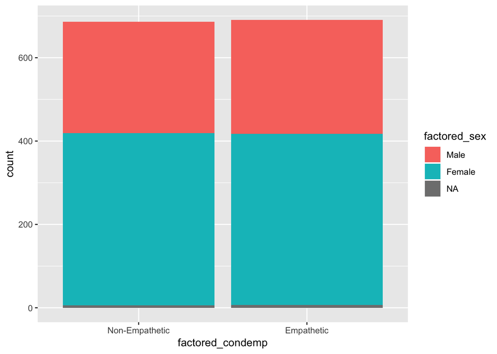

```r
ggplot(project_data_tidied, aes(x=factored_condemp, fill = factored_sex)) + geom_bar()
```

### Correlation between reported mood and dependent variables

Before being exposed to the stimuli, subjects were asked questions about their current mood. These questions were organized into two categories, positive mood and negative mood. In each question the subject was asked to say on a scale from one to five how strongly their current mood correlated with a positive or negative mood. A composite is made from these results to get a value for the subjects positive mood and negative mood, each valued from 1 to 5. The goal of these questions is to evaluate the correlation between the subjects mood at the time of the test and their responses to the questionnaire. If a significant correlation is found then the data being analyzed should be normalized based on this correlation.

Below are the plots of the relationship between mood and the subjects answers to the questionnaire. To make the relationship we are trying to establish more visible, a linear model is created and plotted. There are three categories that subjects were asked to report on: The doctors empathy, the doctors warmth, and the doctors competence. For each of these categories we plot the relationship between the positive mood and negative mood of the subject.

#### Corelation between reported mood and empathy results

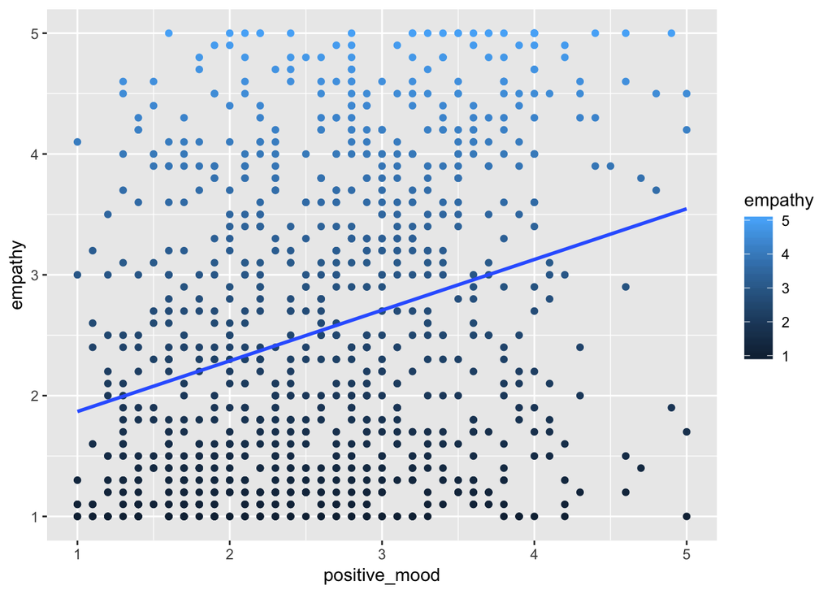

```r
mood_plots <- project_data_tidied %>%
  remove_missing(na.rm=TRUE) %>%
  subset(select = c(empathy, warmth, competence, positive_mood, negative_mood))
ggplot(mood_plots, aes(x = positive_mood, y = empathy)) +
  geom_point(aes(color=empathy)) +
  geom_smooth(method = "lm", se = FALSE)
```

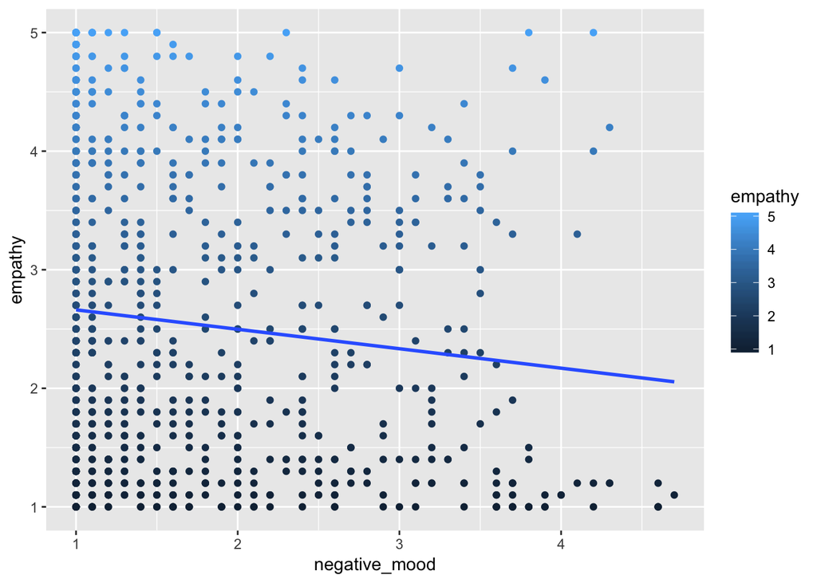

```r
ggplot(mood_plots, aes(x = negative_mood, y = empathy)) +
  geom_point(aes(color=empathy)) +
  geom_smooth(method = "lm", se = FALSE)
```

```r
cor(mood_plots$positive_mood, mood_plots$empathy )
```

```
## [1] 0.2834974
```

```r
cor(mood_plots$negative_mood, mood_plots$empathy )
```

```
## [1] -0.1127482
```

#### Corelation between reported mood and warmth results

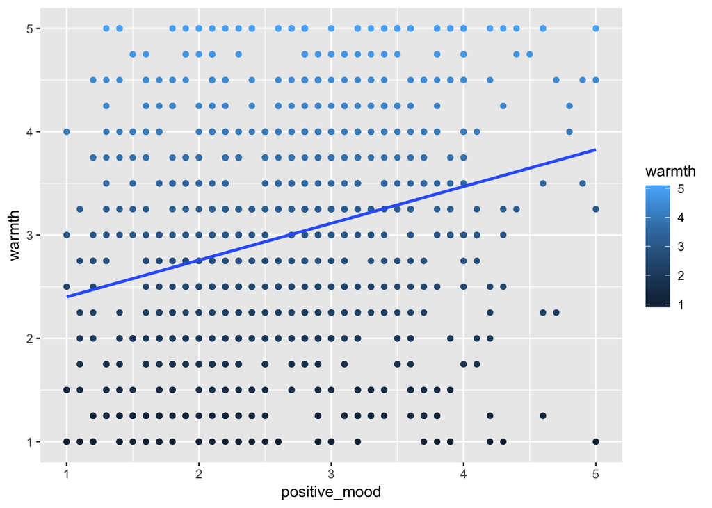

```r
mood_plots <- project_data_tidied %>%
  remove_missing(na.rm=TRUE) %>%
  subset(select = c(empathy, warmth, competence, positive_mood, negative_mood))
ggplot(mood_plots, aes(x = positive_mood, y = warmth)) +
  geom_point(aes(color=warmth)) +
  geom_smooth(method = "lm", se = FALSE)
```

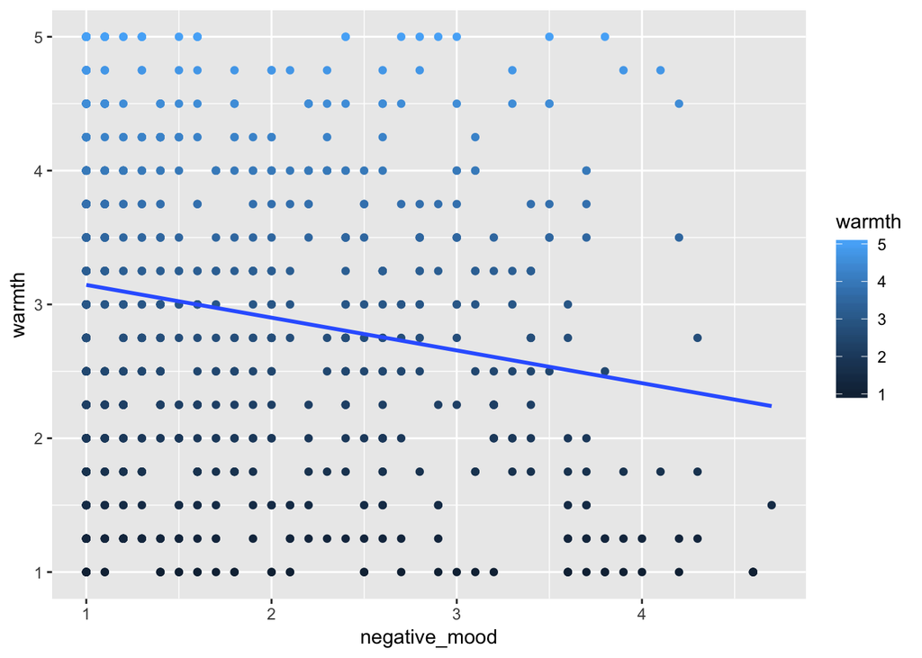

```r
ggplot(mood_plots, aes(x = negative_mood, y = warmth)) +
  geom_point(aes(color=warmth)) +
  geom_smooth(method = "lm", se = FALSE)
```

```r
cor(mood_plots$positive_mood, mood_plots$warmth )
```

```
## [1] 0.2577851
```

```r
cor(mood_plots$negative_mood, mood_plots$warmth )
```

```
## [1] -0.1800976
```

#### Corelation between reported mood and competence results

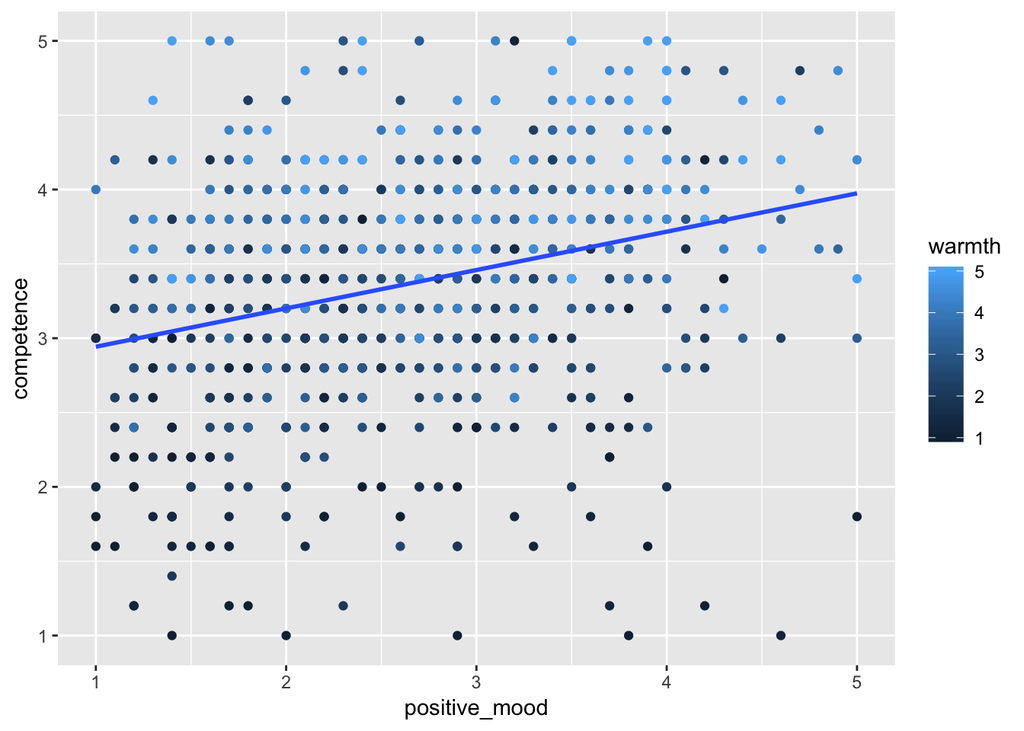

```r
mood_plots <- project_data_tidied %>%
  remove_missing(na.rm=TRUE) %>%
  subset(select = c(empathy, warmth, competence, positive_mood, negative_mood))
ggplot(mood_plots, aes(x = positive_mood, y = competence)) +
  geom_point(aes(color=warmth)) +
  geom_smooth(method = "lm", se = FALSE)
```

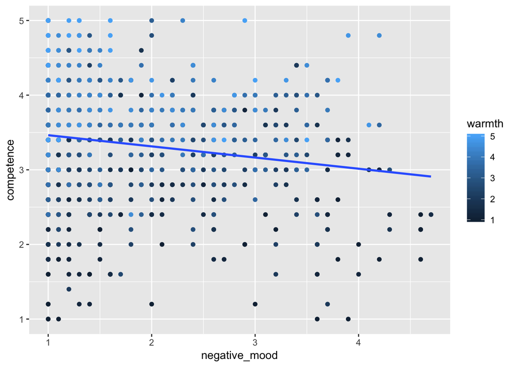

```r
ggplot(mood_plots, aes(x = negative_mood, y = competence)) +
  geom_point(aes(color=warmth)) +
  geom_smooth(method = "lm", se = FALSE)
```

```r
cor(mood_plots$positive_mood, mood_plots$competence )
```

```
## [1] 0.2919784
```

```r
cor(mood_plots$negative_mood, mood_plots$competence )
```

```
## [1] -0.1723623
```

As we can see in the plots, for every category that the subjects were asked to evaluate, there is a noticeable correlation between their mood. Subjects scores for doctor empathy, warmth, and competence all seemed to increase with the initial positive mood of the subject. On the other side, all of these categories also had a negative linear correlation with the initial negative mood of the subject. These observations give us insight into the fact that subject responses are biased based on their mood at the time of filling out the questionnaire. This bias is something that may need to be addressed in the analysis.

### Data Distribution by Stimuli

Here we examine the correlations between empathy, warmth, and competence while separating by the different categories of the stimuli. First lets have a look separating the ggparis plot by the sex of the participant.

```r
library(GGally)
```

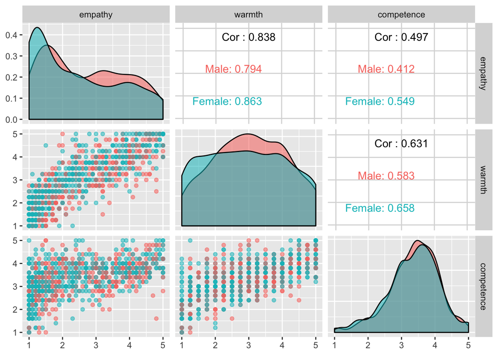

```r
repo_boxplot <- project_data_tidied %>%
  remove_missing(na.rm=TRUE) %>%
  subset(select = c(empathy, warmth, competence, factored_condemp, factored_sex))
ggpairs(repo_boxplot, aes(colour = factored_sex, alpha = 0.7),
        columns = c("empathy", "warmth", "competence"))
```

Here we can see the distribution of scores of the different rating categories based on the sex of the participant. From the graphs we can see that the sex of the participant did not have much of an impact on the scores in the different categories.

Next we look at the results of the tests with respect to the attitude of the doctor in the stimuli.

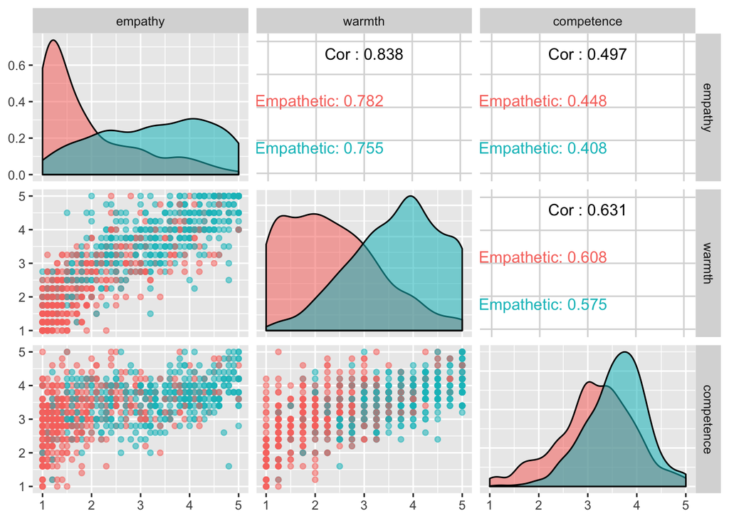

```r
ggpairs(repo_boxplot, aes(colour = factored_condemp, alpha = 0.7),
        columns = c("empathy", "warmth", "competence"))
```

The attitude of the doctors in the stimuli had a much larger impact on the perceived empathy, warmth, and competence of the doctor than the sex of the participant did. For empathy, we see a huge spike in low empathy scores for the non-empathetic category, where the empathetic category is more evenly distributed and skewed to the higher end. For warmth, there is a very clear separation of the means of the scores, with non-empathetic stimuli scoring at the low end of the spectrum and empathetic stimuli scoring on the high end. The competence data is less clear than the other two categories. There still appears to be a lower mean for non-empathetic doctors then empathetic ones.

In both of the plots above, the correlation between the different data are listed. The numbers show a strong correlation between empathy and warmth with lesser correlations between each of those two categories and competence.